# Propriedade Intelectual e Inovação

Gestão de Projetos de Inovação  
com Foco em Propriedade Intelectual

Luiz Diego Vidal Santos

## VisÃ£o Geral

### TÃ³picos Principais

- 1 Evolução dos Modelos de Gestão da Inovação
- 2 ISO 56005 e Sistema de GestÃ£o de PI
- 3 Modelo Stage-Gate
- 4 Indicadores de Desempenho
- 5 Capacidades Organizacionais

**Objetivo Central**

Integrar a propriedade intelectual como componente estratégico transversal em todo o ciclo de inovação, desde a concepção até a comercialização.

## Propriedade Intelectual na Economia do Conhecimento

**Definição Estratégica**

A PI constitui a base jurídica e econômica da economia do conhecimento, funcionando como:

- Instrumento de **incentivo ao investimento**
- Mecanismo de **captura de valor**
- Elemento **estratégico desde a concepção** dos projetos

### MudanÃ§a de Paradigma

**Antes**

- Elemento final do processo
- Tratamento reativo
- DecisÃ£o posterior Ã P&D

**Agora**

- Componente transversal
- Abordagem proativa
- Orientação desde a concepção

# Evolução Histórica

## Taxonomia dos Modelos de Gestão da Inovação

```
timeline
    title Modelos de GestÃ£o da InovaÃ§Ã£o
  1942 : Schumpeter (1942)
     : InovaÃ§Ã£o como "novas combinaÃ§Ãµes" e destruiÃ§Ã£o criativa
    1940-1960 : Modelo Linear (Push)
              : Pesquisa bÃ¡sica â†’ Aplicada â†’ Desenvolvimento â†’ ProduÃ§Ã£o â†’ Mercado
              : Unidirecional e sequencial
    1970-1980 : Modelo Interativo (Kline & Rosenberg, 1986)
              : RetroalimentaÃ§Ãµes mercado-laboratÃ³rio
              : Learning-by-doing
              : Papel do usuÃ¡rio
    1990-2000 : Modelo SistÃªmico (Edquist, 2001)
              : Redes de inovaÃ§Ã£o
              : Triple Helix
              : SNI
    2000-Presente : InovaÃ§Ã£o Aberta (Chesbrough, 2003)
                  : P&D interna + externa
                  : Modelos de negÃ³cio superiores
                  : PI como ativo estratÃ©gico
    2010-Presente : TransformaÃ§Ã£o Digital
                  : IA, IoT, Blockchain
                  : GestÃ£o preditiva e adaptativa
                  : Ecossistemas hiperconectados
```

**Conexão com a redação (Tema 5)**

- Inovação é **não linear** e baseada em aprendizagem/retroalimentação (Kline & Rosenberg, 1986)
- Em projetos, isso exige decisões contínuas sobre **sigilo, documentação e timing de proteção**
- PI deixa de ser “fim do processo” e vira **variável estratégica desde a concepção** (Schumpeter, 1942)

## Do EmpÃrico ao Normativo

**Manual de Oslo (OCDE/Eurostat)**

- Base conceitual para mensuração da inovação
- Taxonomias e indicadores internacionais
- 852 ocorrências de “inovação”
- 619 ocorrÃªncias de “P&D”
- 478 ocorrências de “cooperação”

## Operacionalização ISO 56000

**ISO 56000: Operacionalização**

Transforma conceitos do Manual de Oslo em processos gerenciais:

- âœ“ Rastreabilidade das decisÃµes
- âœ“ Processos auditÃ¡veis
- âœ“ Benchmarking setorial
- âœ“ Comparabilidade internacional

# ISO 56005

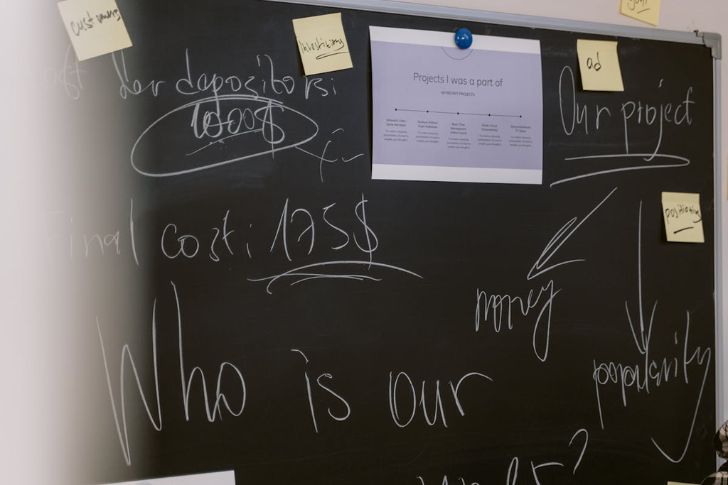

## Estrutura Completa da ISO 56005:2023

[figure not shown]

## Nível 1: Estrutura de Gestão

### Elementos Estruturais

**Comprometimento Organizacional** - Análise do contexto interno/externo - Identificação de partes interessadas - Avaliação de riscos e oportunidades

**Sistema de Gestão** - Processos documentados - Alocação de recursos - Governança clara

### DimensÃµes de Suporte

- ðŸ’¡ **Cultura de PI** - disseminação de conhecimento
- ðŸ‘¥ **Capital Humano** - competências específicas
- âš–ï¸ **Aspectos Legais** - compliance regulatÃ³rio
- ðŸ’° **Dimensão Financeira** - orçamento e ROI

## Nível 2: Estratégia de PI

### Ciclo EstratÃ©gico

```
graph LR
    A[DefiniÃ§Ã£o de Metas] --> B[Desenvolvimento]
    B --> C[ImplementaÃ§Ã£o]
    C --> D[Monitoramento]
    D --> A

    A1[AnÃ¡lise de registros<br/>prÃ³prios e terceiros] -.-> A
    A2[IdentificaÃ§Ã£o de<br/>oportunidades/riscos] -.-> A
    A3[SeleÃ§Ã£o de conceitos] -.-> A

    B1[AnÃ¡lises adicionais] -.-> B
    B2[MitigaÃ§Ã£o de riscos] -.-> B
    B3[ObrigaÃ§Ãµes contratuais] -.-> B
    B4[ManutenÃ§Ã£o de proteÃ§Ãµes] -.-> B

    C1[IntegraÃ§Ã£o ao<br/>planejamento] -.-> C
    C2[Prioridades de<br/>investimento] -.-> C
    C3[Planos de exploraÃ§Ã£o] -.-> C

    style A fill:#4CAF50,stroke:#333,stroke-width:2px,color:#fff
    style B fill:#2196F3,stroke:#333,stroke-width:2px,color:#fff
    style C fill:#FF9800,stroke:#333,stroke-width:2px,color:#fff
    style D fill:#9C27B0,stroke:#333,stroke-width:2px,color:#fff
```

## Nível 3: Integração aos Processos

### Fases de Identificação e Criação

**Identificação de Oportunidades** - Captura de ideias por múltiplos canais - Análise preliminar de PI existente

**Criação de Conceitos** - Comunicação entre P&D, marketing e PI - Avaliação de patenteabilidade

**Validação de Conceitos** - Análise de liberdade de operação - Estudos de viabilidade técnica e jurídica

### Fases de Desenvolvimento e Implantação

- ðŸ”¬ **Desenvolvimento** - Escopo geográfico de proteção
- ðŸ“‹ **Modalidades de PI** - Patentes, marcas, designs
- ðŸ“… **Implantação** - Cronograma de depósitos
- ðŸ’¼ **Estratégias de Exploração** - Licenciamento e comercialização

# Manual de Oslo

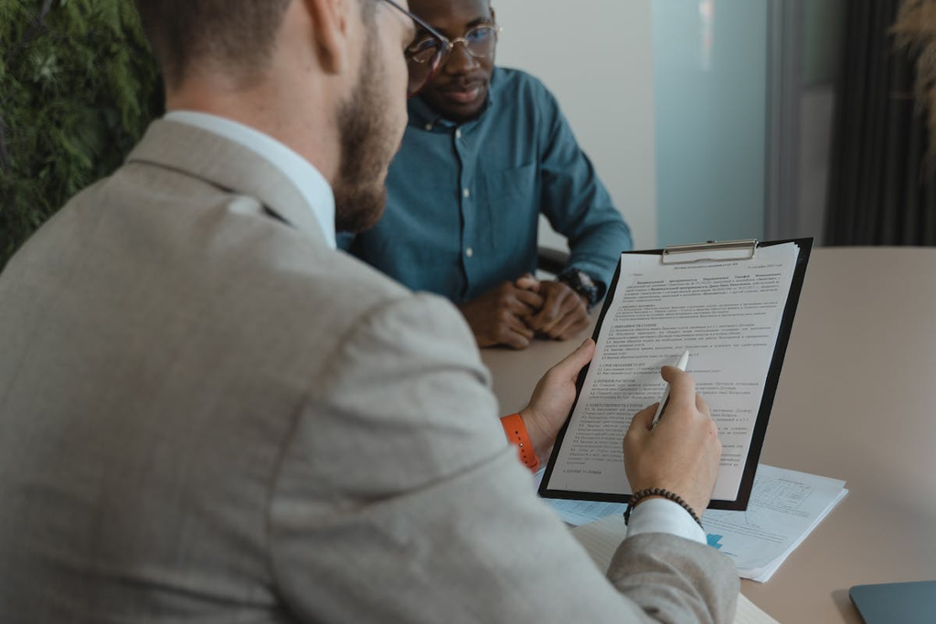

## 7 Categorias de Atividades de Inovação

**Segundo o Manual de Oslo (OCDE/Eurostat, 3Âª ed.)**

1 **P&D Interna e Externa** - Pesquisa básica e aplicada - Contratação de serviços de P&D - *Verificação PI*: Análise de anterioridade

2 **Aquisição de Máquinas/Equipamentos** - Software avançado - Infraestrutura tecnológica - *Verificação PI*: Licenças de software

3 **Aquisição de Conhecimento Externo** - Patentes, licenças - Know-how, marcas - *Verificação PI*: Freedom-to-operate

4 **Treinamento** - Desenvolvimento de competências - Capacitação em PI - *Verificação PI*: Cultura organizacional

5 **Design e Preparação** - Design industrial - Preparação para produção - *Verificação PI*: Registro de design

6 **Introdução no Mercado** - Estudos de mercado - Campanhas de lançamento - *Verificação PI*: Marcas e trade dress

7 **Outras Atividades** - Estudos de viabilidade - Testes e certificações - *Verificação PI*: Documentação técnica

## Integração ISO 56005 + Manual de Oslo

**Alinhamento EstratÃ©gico**

Cada atividade de inovação do Manual de Oslo é acompanhada de verificações de PI conforme ISO 56005, transformando o SGPI em instrumento de:

- ðŸ›¡ï¸ **Mitigação de riscos jurídicos**
- ðŸ’° **Maximização do ROI em inovação**
- ðŸ“Š **Mensuração padronizada**
- ðŸŒ **Comparabilidade internacional**

# Technology Readiness Level

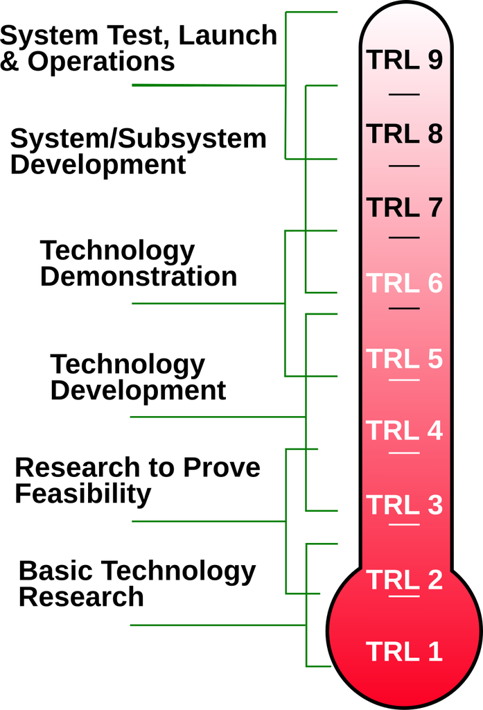

## TRL e EstratÃ©gia de PI

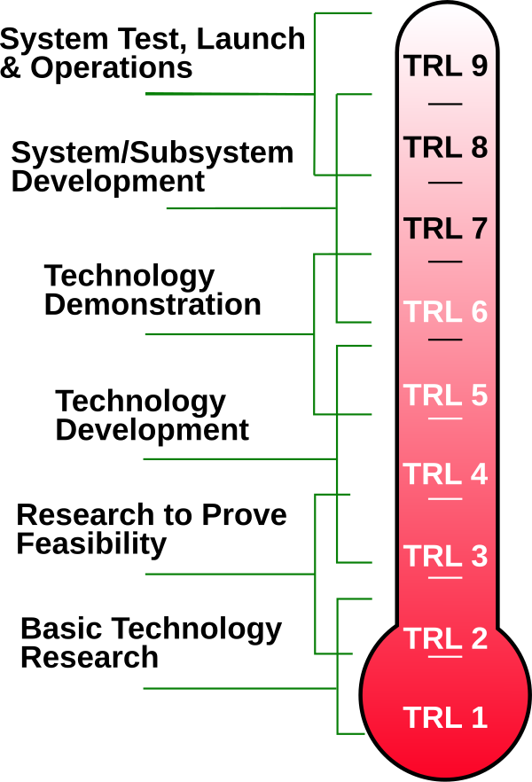

Níveis de Maturidade Tecnológica - Detalhado

## Sincronização TRL-PI

### TRL 1-3: Inicial

**Foco: Sigilo** - Princípios básicos observados - Conceito formulado - Prova de conceito experimental

**Proteção PI:** - âš ï¸ Sigilo rigoroso - ðŸ“„ Publicações estratégicas - ðŸ” Estabelecer prior art

### TRL 4-6: IntermediÃ¡rio

**Foco: Validação** - Validação em laboratório - Validação em ambiente relevante - Demonstração em ambiente operacional

**Proteção PI:** - ðŸ“ Patentes provisórias - ðŸ” Freedom-to-operate - ðŸŒ Definição territorial

### TRL 7-9: AvanÃ§ado

**Foco: Comercialização** - Protótipo em ambiente operacional - Sistema completo qualificado - Sistema comprovado em operação

**Proteção PI:** - âœ… Patentes definitivas - ðŸŽ¨ Registros de design - â„¢ï¸ Marcas comerciais

**Resultado:** Sincronização assegura que recursos não sejam desperdiçados em proteção prematura, evitando divulgações que comprometam a novidade.

## Exemplo: Amostrador de Solo

Exemplo de invenção que completou o ciclo TRL (1-9) com proteção patentária:

- **TRL 1-3:** Concepção e prova de conceito em laboratório
- **TRL 4-6:** Validação em campo e proteção provisória
- **TRL 7-9:** Patente definitiva e transferÃªncia

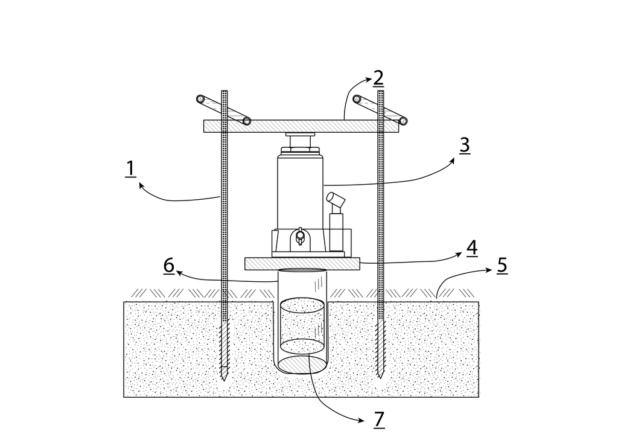

Desenho tÃ©cnico - Patente de amostrador de solo

# Stage-Gate

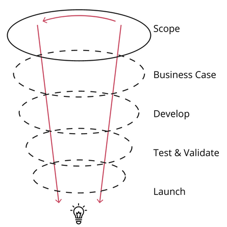

## Modelo Stage-Gate (Cooper, 1990-2008)

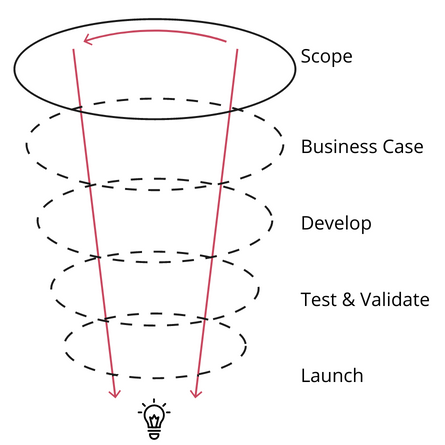

Processo Stage-Gate

## Fases e Gates com PI Integrada

```
graph LR
    I[Ideia] --> G0{Gate 0<br/>Triagem}
    G0 -->|Go| S1[Stage 1<br/>Escopo]

    S1 --> G1{Gate 1<br/>AnÃ¡lise<br/>PI}
    G1 -->|Go| S2[Stage 2<br/>Business Case]
    G1 -->|Kill| K[âŒ]
    S2 --> G2{Gate 2<br/>Viabilidade}

    G2 -->|Go| S3[Stage 3<br/>Desenvolvimento]
    G2 -->|Hold| H[â¸ï¸]
    G2 -->|Kill| K

    S3 --> G3{Gate 3<br/>Teste}
    G3 -->|Go| S4[Stage 4<br/>ValidaÃ§Ã£o]
    S4 --> G4{Gate 4<br/>LanÃ§amento}
    G4 -->|Go| S5[Stage 5<br/>ComercializaÃ§Ã£o]

    style I fill:#003366,color:#fff
    style G0 fill:#FF8C00,color:#fff
    style G1 fill:#FF8C00,color:#fff
    style G2 fill:#FF8C00,color:#fff
    style G3 fill:#FF8C00,color:#fff
    style G4 fill:#FF8C00,color:#fff
    style S1 fill:#4CAF50,color:#fff
    style S2 fill:#4CAF50,color:#fff
    style S3 fill:#00A859,color:#fff
    style S4 fill:#4CAF50,color:#fff
    style S5 fill:#0066CC,color:#fff
    style K fill:#CC0000,color:#fff
    style H fill:#CCCC00,color:#000
```

## Stage-Gate + TRL + Desenvolvimento de Patentes

```
graph TB
    subgraph "Stage 1: Escopo (TRL 1-2)"
    A[Busca Preliminar<br/>Anterioridade] --> B[Disclosure de<br/>InvenÃ§Ã£o]
    B --> C[Segredo ou<br/>PublicaÃ§Ã£o?]
    end

    subgraph "Stage 2: Business Case (TRL 3-4)"
    D[Busca Completa<br/>Anterioridade] --> E[AnÃ¡lise FTO]
    E --> F[EstratÃ©gia Territorial]
    F --> G[OrÃ§amento PI]
    end

    subgraph "Stage 3: Desenvolvimento (TRL 5-6)"
    H[DepÃ³sito Patente<br/>ProvisÃ³rio] --> I[ValidaÃ§Ã£o<br/>TÃ©cnica]
    I --> J[Patente Definitiva<br/>+ PCT?]
    end

    subgraph "Stage 4: ValidaÃ§Ã£o (TRL 7-8)"
    K[ProteÃ§Ã£o<br/>Complementar] --> L[Design Industrial<br/>Marca]
    L --> M[ValoraÃ§Ã£o de<br/>Ativos]
    end

    subgraph "Stage 5: ComercializaÃ§Ã£o (TRL 9)"
    N[Licenciamento] --> O[Spin-off]
    O --> P[ExploraÃ§Ã£o<br/>Direta]
    end

    C --> D
    G --> H
    J --> K
    M --> N

    style A fill:#003366,color:#fff
    style H fill:#00A859,color:#fff
    style M fill:#FF8C00,color:#fff
    style P fill:#0066CC,color:#fff
```

## Exemplo: PermeÃ¢metro Patenteado

O permeâmetro ilustra uma invenção que percorreu todo o fluxo Stage-Gate + TRL:

- **Stage 1 (Scoping):** Identificação da necessidade de medir permeabilidade *in situ*
- **Stage 3 (Desenvolvimento):** Protótipo funcional + depósito provisório
- **Stage 5 (LanÃ§amento):** Patente concedida + licenciamento

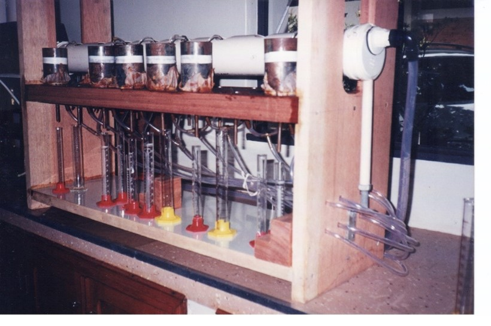

## ConvergÃªncia Stage-Gate + ISO 56005

**Harmonização Estratégica**

Quando o modelo Stage-Gate Ã© harmonizado com a ISO 56005, cada gate incorpora:

### EntregÃ¡veis de PI

- ðŸ“‹ RelatÃ³rios de anterioridade
- ðŸ” AnÃ¡lises de freedom-to-operate
- ðŸ’¡ Formulários de divulgação de invenções
- ðŸŒ EstratÃ©gias territoriais
- ðŸ’¼ Planos de exploração comercial

### BenefÃcios

- âœ… Rastreabilidade das decisÃµes
- âš–ï¸ Proteção jurídica em cada etapa
- ðŸ“Š GovernanÃ§a aprimorada
- ðŸŽ¯ SGPI operacional efetivo

## Artefatos da ISO 56005

**Anexos Informativos da ABNT NBR ISO 56005:2023**

A norma detalha instrumentos práticos para padronizar coleta de informações e tomada de decisão:

### Documentos Estruturados

1. **Invention Disclosure Form**
   - Formulário de divulgação de invenção
   - Captura sistemática de informações
   - Padronização de dados
2. **Employee PI Management Guide**
   - Guia para atividades de PI com funcionÃ¡rios
   - Direitos e deveres
   - Incentivos Ã divulgação

### Ferramentas de Avaliação

3. **DPI Assessment Tools**
   - Ferramentas para avaliação de PI
   - AnÃ¡lise de valor
   - Priorização de ativos

**Objetivo:** Transformar conhecimento tácito em processos estruturados e auditáveis dentro do SGPI

# Indicadores de Desempenho

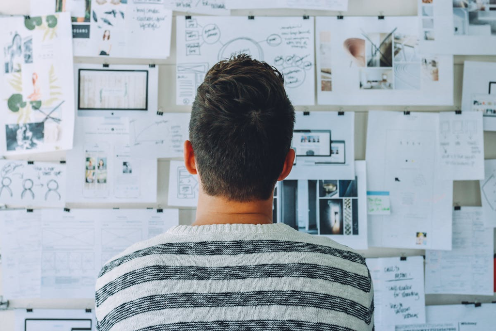

## Framework de Indicadores (Manual de Oslo)

### Indicadores de INPUT

- ðŸ’° Investimento total em atividades de inovação
- ðŸ” Recursos em busca de anterioridade
- ðŸ“Š Recursos em anÃ¡lise de freedom-to-operate
- ðŸ’³ Custos de depósito e manutenção de ativos

### Indicadores de PROCESSO

- â±ï¸ Tempo médio: invenção â†’ decisão de proteção
- âœ… Taxa de aprovação nos gates
- ðŸŽ¯ Alinhamento portfólio PI vs estratégia

### Indicadores de OUTPUT

- ðŸ“œ NÃºmero de patentes **concedidas**
- ðŸ’» Registros de software efetivados
- ðŸ¤ Contratos de licenciamento firmados
- ðŸ’µ Receita de royalties

### Indicadores de IMPACTO

- ðŸ“ˆ % receita de produtos com PI
- ðŸ† Market share de inovações patenteadas
- ðŸ’¹ Redução de custos operacionais
- ðŸŒŸ Valor de mercado atribuÃvel a PI

## Arquitetura de Indicadores Integrada

```
graph TB
    A[Framework de Indicadores<br/>Manual de Oslo + ISO 56005]

    B[INPUT]
    C[PROCESSO]
    D[OUTPUT]
    E[IMPACTO]

    A --> B
    A --> C
    A --> D
    A --> E

    B --> B1[Investimento em<br/>atividades de inovaÃ§Ã£o]
    B --> B2[Recursos em PI<br/>busca + anÃ¡lise]

    C --> C1[Tempo mÃ©dio<br/>invenÃ§Ã£o â†’ proteÃ§Ã£o]
    C --> C2[Taxa aprovaÃ§Ã£o<br/>gates decisÃ³rios]
    C --> C3[Alinhamento<br/>portfÃ³lio-estratÃ©gia]

    D --> D1[Patentes concedidas]
    D --> D2[Contratos de<br/>licenciamento]
    D --> D3[Receita de royalties]

    E --> E1[% receita de<br/>produtos com PI]
    E --> E2[Market share<br/>inovaÃ§Ãµes patenteadas]
    E --> E3[Valor de mercado<br/>atribuÃvel a PI]

    T1[TRL 1-3] -.-> B
    T2[TRL 4-6] -.-> C
    T3[TRL 7-9] -.-> D
    T4[Comercial] -.-> E

    SG[Stage-Gate<br/>Gates 1-5] -.-> C

    style A fill:#00703C,stroke:#333,stroke-width:3px,color:#fff
    style B fill:#2196F3,stroke:#333,stroke-width:2px,color:#fff
    style C fill:#4CAF50,stroke:#333,stroke-width:2px,color:#fff
    style D fill:#FF9800,stroke:#333,stroke-width:2px,color:#fff
    style E fill:#9C27B0,stroke:#333,stroke-width:2px,color:#fff
```

## Mensuração e Decisão Estratégica

**Alinhamento TRL + Stage-Gate + Indicadores**

A arquitetura de indicadores permite:

1. ðŸ“Š Avaliar eficácia do SGPI em diferentes estágios de maturidade tecnológica
2. ðŸŽ¯ Orientar decisÃµes de continuidade/descontinuidade de projetos
3. ðŸ”„ Melhoria contínua baseada em evidências
4. ðŸŒ Benchmarking com padrÃµes internacionais

# Capacidades Organizacionais

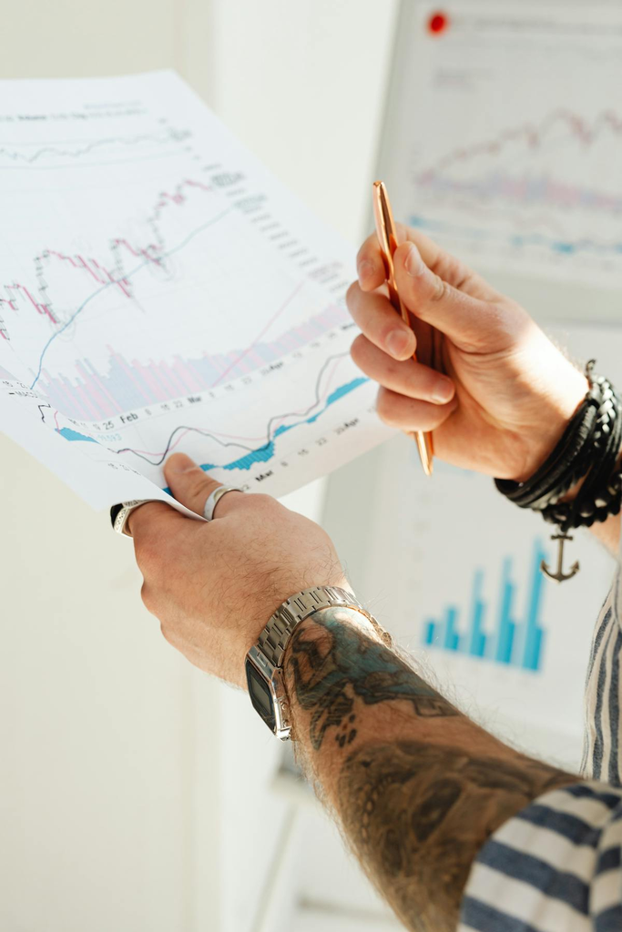

## Fundamentos das Capacidades

[figure not shown]

## Modelo de Capacidade Absortiva

```
flowchart LR
    %% Blocos principais
    A[Fontes de conhecimento<br/>Complementaridade<br/>ExperiÃªncia] --> B
    B["<b>Capacidade Absortiva Potencial</b><br/>AquisiÃ§Ã£o â€¢ AssimilaÃ§Ã£o"] --> C
    C["<b>Capacidade Absortiva Realizada</b><br/>TransformaÃ§Ã£o â€¢ ExploraÃ§Ã£o"] --> D
    D[Vantagem competitiva<br/>Flexibilidade estratÃ©gica<br/>InovaÃ§Ã£o â€¢ Performance]

    %% Gatilhos e mecanismos
    E((Gatilhos)) -.-> B
    F((Mecanismos de<br/>integraÃ§Ã£o social)) -.-> C
    G((Regime de<br/>apropriaÃ§Ã£o)) -.-> D

    style A fill:#0066CC,stroke:#003366,stroke-width:2px,color:#fff,font-weight:bold
    style B fill:#0099FF,stroke:#003366,stroke-width:2px,color:#fff,font-weight:bold
    style C fill:#00A859,stroke:#004D2E,stroke-width:2px,color:#fff,font-weight:bold
    style D fill:#003366,stroke:#001a33,stroke-width:2px,color:#fff,font-weight:bold
    style E fill:#FF8C00,stroke:#CC6600,stroke-width:2px,color:#fff,font-weight:bold
    style F fill:#FF8C00,stroke:#CC6600,stroke-width:2px,color:#fff,font-weight:bold
    style G fill:#FF8C00,stroke:#CC6600,stroke-width:2px,color:#fff,font-weight:bold
```

**Cohen & Levinthal (1990):** Aptidão de reconhecer, assimilar e aplicar comercialmente conhecimento externo, dependente de trajetórias anteriores de investimento (path dependency)

## DimensÃµes da Capacidade Absortiva

### Capacidade Potencial

**1. Aquisição** - Identificação de conhecimento valioso - Monitoramento tecnológico - Scanning do ambiente

**2. Assimilação** - Absorção de conhecimento externo - Tradução para contexto interno - Codificação e armazenamento

### Capacidade Realizada

**3. Transformação** - Combinação com conhecimento existente - Reconfiguração de recursos - Adaptação organizacional

**4. Exploração** - Aplicação comercial - Geração de inovação - Captura de valor

## Capacidades DinÃ¢micas (Teece, 2007)

[figure not shown]

Capacidades DinÃ¢micas

## Modelo de Capacidades DinÃ¢micas (Teece, 2007)

```
flowchart LR
    %% Elementos componentes Ã  esquerda
    A1[Comportamentos e habilidades<br/>de mudanÃ§a e inovaÃ§Ã£o] --> C
    A2[Processos e rotinas de<br/>busca ou inovaÃ§Ã£o] --> C
    A3[Mecanismos de aprendizagem<br/>e governanÃ§a do conhecimento] --> C

    %% Bloco central
    C([<b>Capacidades<br/>DinÃ¢micas</b>])

    %% Indicadores Ã  direita
    C --> B1[GeraÃ§Ã£o de ideias e<br/>introduÃ§Ã£o de rupturas]
    C --> B2[MudanÃ§as<br/>organizacionais]
    C --> B3[InovaÃ§Ã£o e<br/>novos mercados]

    style A1 fill:#0099FF,stroke:#003366,stroke-width:2px,color:#fff,font-weight:bold
    style A2 fill:#0099FF,stroke:#003366,stroke-width:2px,color:#fff,font-weight:bold
    style A3 fill:#0099FF,stroke:#003366,stroke-width:2px,color:#fff,font-weight:bold
    style B1 fill:#00A859,stroke:#004D2E,stroke-width:2px,color:#fff,font-weight:bold
    style B2 fill:#00A859,stroke:#004D2E,stroke-width:2px,color:#fff,font-weight:bold
    style B3 fill:#00A859,stroke:#004D2E,stroke-width:2px,color:#fff,font-weight:bold
    style C fill:#003366,stroke:#001a33,stroke-width:3px,color:#fff,font-weight:bold,font-size:16px
```

## Três Pilares das Capacidades Dinâmicas

### 1 Sensing

**Perceber Oportunidades**

- Scanning do ambiente
- Identificação de tendências
- Monitoramento de concorrentes
- AnÃ¡lise de sinais fracos

### 2 Seizing

**Mobilizar Recursos**

- Alocação de recursos
- Estruturação de projetos
- DecisÃµes de investimento
- Formação de parcerias

### 3 Transforming

**Transformar Ativos**

- Reconfiguração contínua
- Adaptação Ã mudança
- Renovação da base de ativos
- Evolução organizacional

**Contexto:** Habilidade essencial em ambientes incertos e turbulentos, permitindo transformação contínua da organização

## Cultura de Propriedade Intelectual

**Seção 4.4 da NBR ISO 56005:2023**

Elemento essencial previsto na norma, sustentado pelas capacidades absortiva e dinÃ¢mica

### Componentes da Cultura de PI

1. **Disseminação de Conhecimento**
   - Treinamentos regulares
   - Workshops sobre PI
   - Materiais educativos
2. **Incentivo Ã Divulgação**
   - Reconhecimento de inventores
   - Recompensas por divulgações
   - Facilitação do processo
3. **Promoção da Confidencialidade**
   - PolÃticas de sigilo
   - NDAs padronizados
   - Gestão de acesso Ã informação
4. **Cumprimento de Prazos Legais**
   - CalendÃ¡rio de PI
   - Alertas automÃ¡ticos
   - Responsabilidades definidas

**Resultado:** Ambidestria organizacional - equilíbrio entre exploração de novas oportunidades e eficiência na proteção/valorização de ativos existentes

# Ferramentas de PI

## Ferramentas AnalÃticas de PI

**Instrumentos de Apoio Ã DecisÃ£o**

A ISO 56005 é apoiada por ferramentas que padronizam coleta de informações e subsidiam decisões técnicas e estratégicas

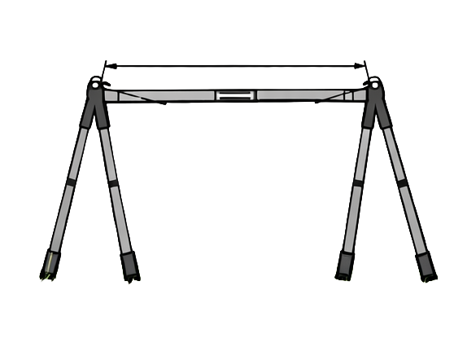

Aparelho de vistada de amostra de solo - exemplo de invenção sujeita a análise FTO e Patent Landscape

### Ferramentas de Análise Técnica

**1. Paisagem Patentária (Patent Landscape)** - Mapeamento tecnológico completo - Identificação de white spaces - Análise de tendências de patenteamento - Posicionamento competitivo

**2. Freedom-to-Operate (FTO)** - Análise de risco de infração - Identificação de patentes bloqueadoras - Estratégias de contorno (design around) - Due diligence jurídica

### Ferramentas de Valoração

**3. Valoração de Intangíveis** - **Método de Custo:** custos de desenvolvimento - **Método de Mercado:** transações comparáveis - **Método de Renda:** fluxo de caixa futuro - **Opções Reais:** flexibilidade estratégica

**Integração:** Ferramentas usadas em diferentes gates do Stage-Gate conforme maturidade tecnológica (TRL)

## Artefatos Padronizados ISO 56005

**ABNT NBR ISO 56005:2023 - Anexos Informativos**

Instrumentos práticos que transformam conhecimento tácito em processos estruturados e auditáveis

```
graph TB
    A[Artefatos ISO 56005]

    B[Invention Disclosure Form]
    C[Employee PI Guide]
    D[DPI Assessment Tools]
    E[Contract Management]

    A --> B
    A --> C
    A --> D
    A --> E

    B --> B1[Captura sistemÃ¡tica<br/>de informaÃ§Ãµes]
    B --> B2[DescriÃ§Ã£o tÃ©cnica<br/>detalhada]
    B --> B3[IdentificaÃ§Ã£o de<br/>inventores]
    B --> B4[AvaliaÃ§Ã£o preliminar<br/>de patenteabilidade]

    C --> C1[Direitos e deveres<br/>dos funcionÃ¡rios]
    C --> C2[Incentivos Ã <br/>divulgaÃ§Ã£o]
    C --> C3[PolÃticas de<br/>confidencialidade]
    C --> C4[Cumprimento de<br/>prazos legais]

    D --> D1[AnÃ¡lise de valor<br/>de ativos]
    D --> D2[PriorizaÃ§Ã£o de<br/>proteÃ§Ãµes]
    D --> D3[GestÃ£o de<br/>portfÃ³lio]
    D --> D4[DecisÃµes de<br/>manutenÃ§Ã£o]

    E --> E1[Guias de PI em<br/>contratos]
    E --> E2[ClÃ¡usulas<br/>padronizadas]
    E --> E3[NDAs e<br/>confidencialidade]
    E --> E4[Acordos de<br/>co-desenvolvimento]

    style A fill:#00703C,stroke:#333,stroke-width:3px,color:#fff
    style B fill:#2196F3,stroke:#333,stroke-width:2px,color:#fff
    style C fill:#4CAF50,stroke:#333,stroke-width:2px,color:#fff
    style D fill:#FF9800,stroke:#333,stroke-width:2px,color:#fff
    style E fill:#9C27B0,stroke:#333,stroke-width:2px,color:#fff
```

## Formulário de Divulgação de Invenção

### Seções Principais do IDF

**1. Informações Básicas** - Título da invenção - Data de concepção - Lista de inventores e contribuições - Vínculo institucional

**2. Descrição Técnica** - Problema técnico resolvido - Estado da técnica (prior art) - Solução proposta - Vantagens e diferenciais

**3. Aspectos Comerciais** - Aplicações potenciais - Mercados-alvo - Competidores conhecidos - Estimativa de demanda

**4. Informações de PI** - Divulgações anteriores - Publicações relacionadas - Segredos comerciais envolvidos - Urgência de proteção

**Função:** Captura sistemática que alimenta decisões de proteção nos gates do Stage-Gate

# Colaboração e PI

## GestÃ£o de PI em Projetos Colaborativos

**RelevÃ¢ncia (Manual de Oslo)**

Cooperação identificada como fonte primária de conhecimento externo para inovação

**478 ocorrÃªncias** no Manual de Oslo

### Desafios em Co-desenvolvimento

- MÃºltiplos parceiros
- Contribuições heterogêneas
- Assimetrias informacionais
- Risco de conflitos futuros
- Complexidade contratual

### ExigÃªncias do SGPI (ex ante)

1. **Regime de Titularidade**
   - PI conjunta
   - PI separada
   - PI proporcional Ã contribuição
2. **Direitos de Exploração**
   - Exclusivos vs nÃ£o-exclusivos
   - Territorialidade
   - Sublicenciamento

## Definições Contratuais Ex Ante

**PrincÃpio Fundamental**

Todos os aspectos de PI devem ser estabelecidos **antes** (ex ante) do inÃcio do projeto colaborativo

### 1. Regime de Titularidade

**Opções de Titularidade:**

- **PI Conjunta (Joint Ownership)**
  - Todos os parceiros co-titulares
  - DecisÃµes por consenso
- **PI Separada**
  - Cada parceiro titular de suas contribuições
  - Licenças cruzadas quando necessário
- **PI Proporcional**
  - Titularidade proporcional Ã contribuição
  - Requer métrica de avaliação acordada

### 2. Direitos de Exploração

**Definições Necessárias:**

- **Exclusividade**
  - Direitos exclusivos vs nÃ£o-exclusivos
  - Por território geográfico
  - Por campo de aplicação
- **Sublicenciamento**
  - PermissÃ£o para sublicenciar
  - Condições e royalties
- **Background vs Foreground IP**
  - Conhecimento prÃ©vio (background)
  - Conhecimento gerado (foreground)

## Instrumentos de GestÃ£o Colaborativa

**Recomendações da ISO 56005**

Uso de instrumentos padronizados para reduzir custos de transação e assimetrias informacionais

### Documentos Contratuais

- ðŸ“„ **Term Sheets**
  - Termos preliminares nÃ£o-vinculantes
  - Intenções e objetivos das partes
  - Base para negociação detalhada
- ðŸ¤ **Acordos de Co-desenvolvimento**
  - Responsabilidades tÃ©cnicas detalhadas
  - Marcos (milestones) e entregÃ¡veis
  - Cronogramas e orÃ§amentos
- âš–ï¸ **Joint Ownership Agreements**
  - Titularidade compartilhada definida
  - Regras de exploração comercial
  - Divisão de custos de manutenção

### ClÃ¡usulas Essenciais

**3. Confidencialidade e Não-Competição** - NDAs específicos para o projeto - Períodos de proteção pós-projeto - Exceções permitidas

**4. Resolução de Disputas** - Arbitragem como primeira instância - Mediação prévia obrigatória - Jurisdição e lei aplicável - Cláusulas escalonadas (escalation)

**Benefício:** Clareza contratual prévia mitiga conflitos futuros e acelera comercialização conjunta

## Redução de Custos de Transação

```
graph LR
    A[Instrumentos<br/>Padronizados<br/>ISO 56005] --> B[ReduÃ§Ã£o de<br/>Assimetrias<br/>Informacionais]

    B --> C[Menor Custo<br/>de TransaÃ§Ã£o]

    C --> D[AceleraÃ§Ã£o<br/>da ComercializaÃ§Ã£o]

    E[Term Sheets] --> A
    F[Co-dev Agreements] --> A
    G[Joint Ownership] --> A
    H[NDAs Padronizados] --> A

    D --> I[Maior ROI<br/>em P&D<br/>Colaborativo]
    D --> J[Parcerias<br/>Mais Ãgeis]
    D --> K[Menos<br/>LitÃgios]

    style A fill:#00703C,stroke:#333,stroke-width:3px,color:#fff
    style B fill:#2196F3,stroke:#333,stroke-width:2px,color:#fff
    style C fill:#4CAF50,stroke:#333,stroke-width:2px,color:#fff
    style D fill:#FF9800,stroke:#333,stroke-width:2px,color:#fff
    style I fill:#9C27B0,stroke:#333,stroke-width:2px,color:#fff
    style J fill:#9C27B0,stroke:#333,stroke-width:2px,color:#fff
    style K fill:#9C27B0,stroke:#333,stroke-width:2px,color:#fff
```

**Teoria dos Custos de Transação (Williamson, 1985):** Contratos bem estruturados reduzem oportunismo e incerteza, facilitando cooperação

# Obstáculos Ã Inovação

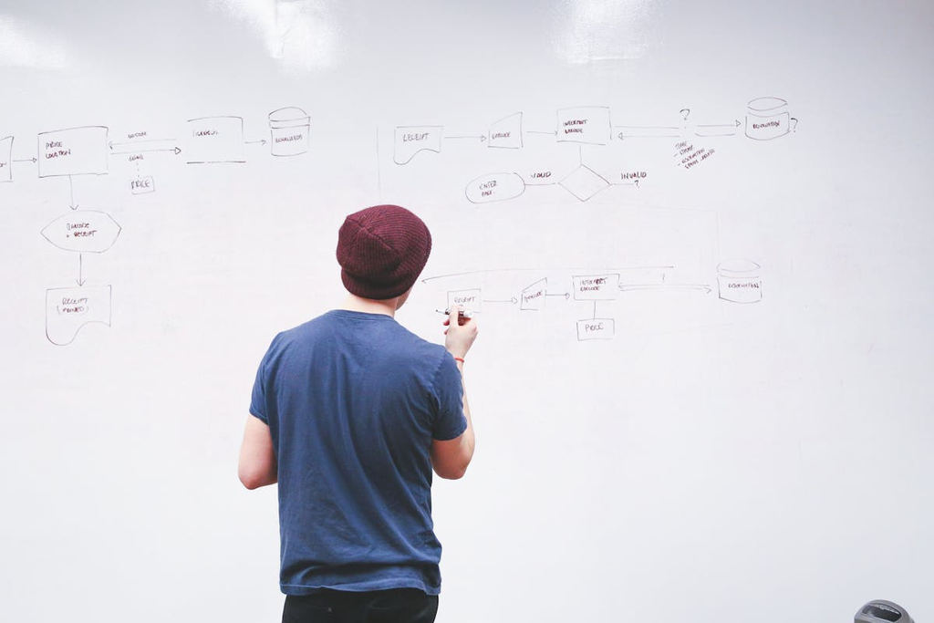

## 4 Dimensões de Obstáculos (Manual de Oslo)

```
graph TB
    A[ObstÃ¡culos Ã  GestÃ£o de PI<br/>em Projetos de InovaÃ§Ã£o]

    B[EconÃ´micos]
    C[Conhecimento]
    D[Mercado]
    E[Institucionais]

    A --> B
    A --> C
    A --> D
    A --> E

    B --> B1[Custos de<br/>patenteamento<br/>internacional]
    B --> B2[ManutenÃ§Ã£o de<br/>portfÃ³lios extensos]
    B --> B3[Valley of death:<br/>financiamento-ponte]

    C --> C1[Falta de pessoal<br/>qualificado em PI]
    C --> C2[Assimetrias na<br/>valoraÃ§Ã£o de ativos]
    C --> C3[Desconhecimento<br/>de mecanismos]

    D --> D1[Incerteza sobre<br/>demanda futura]
    D --> D2[Dificuldade de<br/>identificar parceiros]
    D --> D3[Mercados dominados<br/>por patentes essenciais]

    E --> E1[Backlog do INPI:<br/>morosidade]
    E --> E2[DivergÃªncias<br/>regulatÃ³rias]
    E --> E3[Fragilidades no<br/>enforcement]

    style A fill:#00703C,stroke:#333,stroke-width:3px,color:#fff
    style B fill:#F44336,stroke:#333,stroke-width:2px,color:#fff
    style C fill:#FF9800,stroke:#333,stroke-width:2px,color:#fff
    style D fill:#2196F3,stroke:#333,stroke-width:2px,color:#fff
    style E fill:#9C27B0,stroke:#333,stroke-width:2px,color:#fff
```

## Mitigação de Obstáculos

**Proposta da ISO 56005**

O SGPI deve incorporar análise sistemática de obstáculos com planos de mitigação específicos para cada categoria

### Estratégias Econômicas

- ðŸ’° Priorização territorial inteligente
- ðŸ¤ Consórcios para redução de custos
- ðŸ’µ Acesso a fundos de inovação
- ðŸ“Š Gestão de portfólio otimizada

### EstratÃ©gias de Conhecimento

- ðŸŽ“ Programas de capacitação contínua
- ðŸ” Parcerias com especialistas
- ðŸ“š Bases de conhecimento internas
- ðŸ›ï¸ Colaboração com ICTs

### EstratÃ©gias de Mercado

- ðŸ“ˆ Estudos de inteligÃªncia competitiva
- ðŸŒ Plataformas de matching
- ðŸ”“ AnÃ¡lise de patent pools
- ðŸ¤ Licenciamento cruzado

### EstratÃ©gias Institucionais

- âš¡ Exame prioritÃ¡rio (fast-track)
- ðŸŒ Protocolo PCT estratÃ©gico
- âš–ï¸ Arbitragem alternativa
- ðŸ›¡ï¸ Seguros de PI

## ResiliÃªncia do SGPI

**Objetivo da Análise de Obstáculos**

Assegurar **resiliência** dos projetos de inovação diante de adversidades previsíveis, transformando riscos em oportunidades de melhoria contínua

**Resultado Esperado:**

- âœ… Antecipação de problemas
- ðŸŽ¯ Planos de contingÃªncia
- ðŸ“Š Monitoramento sistemÃ¡tico
- ðŸ”„ Aprendizado organizacional

# Marco RegulatÃ³rio

## Integração: Ferramentas + Marco Legal + Indicadores

**Ecossistema Completo de GestÃ£o de PI**

A ISO 56005 integra ferramentas analÃticas, marco legal e indicadores de desempenho em sistema coeso

```
graph TB
    A[Sistema de GestÃ£o<br/>de PI - SGPI]

    B[Ferramentas<br/>AnalÃticas]
    C[Marco Legal<br/>Brasileiro]
    D[Indicadores de<br/>Desempenho]

    A --> B
    A --> C
    A --> D

    B --> B1[Paisagem PatentÃ¡ria]
    B --> B2[Freedom-to-Operate]
    B --> B3[ValoraÃ§Ã£o]
    B --> B4[IDF]

    C --> C1[Lei 9.279/1996<br/>Propriedade Industrial]
    C --> C2[Lei 10.973/2004<br/>InovaÃ§Ã£o]
    C --> C3[Res. CNPq 30/2020<br/>Bolsas]
    C --> C4[Port. MCTI 1.122/2020<br/>ICTs]

    D --> D1[Input:<br/>Investimentos]
    D --> D2[Processo:<br/>Tempo/Qualidade]
    D --> D3[Output:<br/>Patentes/Contratos]
    D --> D4[Impacto:<br/>Receita/Market Share]

    E[Rastreabilidade<br/>TransparÃªncia<br/>Conformidade] --> A

    style A fill:#00703C,stroke:#333,stroke-width:4px,color:#fff
    style B fill:#2196F3,stroke:#333,stroke-width:2px,color:#fff
    style C fill:#FF9800,stroke:#333,stroke-width:2px,color:#fff
    style D fill:#9C27B0,stroke:#333,stroke-width:2px,color:#fff
    style E fill:#4CAF50,stroke:#333,stroke-width:2px,color:#fff
```

## Ferramentas AnalÃticas Integradas

### Instrumentos de Apoio Ã DecisÃ£o

**1. Paisagem Patentária (Patent Landscape)** - Mapeamento tecnológico completo do setor - Identificação de white spaces (oportunidades) - Análise de tendências temporais - Posicionamento competitivo relativo

**2. Análise de Liberdade de Operação (FTO)** - Identificação de patentes bloqueadoras - Avaliação de risco de infração - Estratégias de design around - Due diligence jurídica pré-investimento

**3. Valoração de Intangíveis** - **Custo:** custos históricos de P&D - **Mercado:** transações comparáveis - **Renda:** fluxo de caixa descontado - **Opções Reais:** flexibilidade de expansão

**4. FormulÃ¡rios e Guias** - Invention Disclosure Form (IDF) - Employee PI Management Guide - Contract Management Templates - DPI Assessment Tools

**Função:** Reduzir assimetrias informacionais e subsidiar decisões nos gates do Stage-Gate

## Marco Legal Brasileiro AplicÃ¡vel

**Arcabouço Regulatório para Gestão de PI em Projetos de Inovação**

### Legislação Fundamental

**âš–ï¸ Lei nº 9.279/1996 - LPI** - Regula direitos e obrigações de PI - Define patenteabilidade e exclusões - Procedimentos de depósito e concessão - Infrações e penalidades

**ðŸ”¬ Lei nº 10.973/2004 - Lei de Inovação** - Incentivos Ã inovação no ambiente produtivo - Participação de ICTs em projetos - Compartilhamento de laboratórios - Criação de NITs (Núcleos de Inovação)

### Regulamentação Complementar

**ðŸŽ“ Resolução CNPq nº 30/2020** - Disciplina concessão de bolsas de pesquisa - Define titularidade de PI em bolsas - Estabelece direitos e deveres de bolsistas - Regula compartilhamento de benefícios

**ðŸ›ï¸ Portaria MCTI nº 1.122/2020** - Diretrizes para gestão de PI em ICTs - Política institucional de PI obrigatória - Composição e atribuições dos NITs - Prestação de contas de resultados

## Rastreabilidade e TransparÃªncia do SGPI

**ISO 56005 + Marco Legal: Sistema AuditÃ¡vel**

A combinação de ferramentas padronizadas com arcabouço legal robusto fortalece governança da inovação

### Rastreabilidade

- ðŸ“‹ **Documentação Completa**
  - Todas as decisÃµes de PI registradas
  - FormulÃ¡rios padronizados (IDF, etc.)
- ðŸ”— **Trilhas de Auditoria**
  - Histórico de avaliações e pareceres
  - Versionamento de decisÃµes
- â±ï¸ **Cronogramas VerificÃ¡veis**
  - Cumprimento de prazos legais
  - Alertas automÃ¡ticos de deadlines

### TransparÃªncia

- ðŸ‘ï¸ **Visibilidade de Processos**
  - Dashboards de acompanhamento
  - Relatórios periódicos
- ðŸ“ˆ **Indicadores PÃºblicos**
  - Input, processo, output, impacto
  - Comparabilidade com benchmarks
- âœ… **Conformidade RegulatÃ³ria**
  - Alinhamento com Lei de Inovação
  - Prestação de contas a agências de fomento

**Resultado:** SGPI que transforma práticas empíricas em processos estruturados, mensuráveis e auditáveis

# ConclusÃ£o

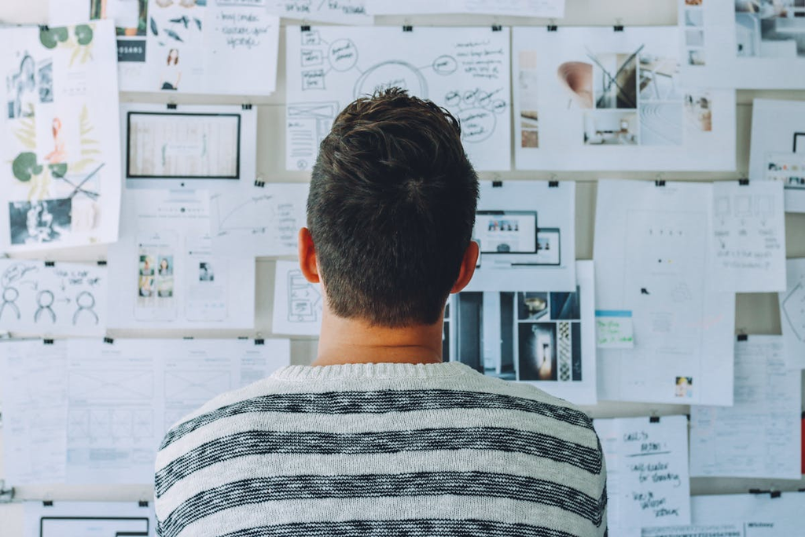

## Síntese: Integração PI-Inovação

**Elemento Central para Competitividade**

A integração entre gestão da inovação e propriedade intelectual constitui elemento central para a competitividade e sustentabilidade tecnológica das organizações

### Evolução Histórica

- Modelos lineares â†’ interativos â†’ abertos
- Empirismo â†’ padronização normativa
- ISO 56000 + Manual de Oslo

### Instrumentos Operacionais

- Stage-Gate harmonizado com ISO 56005
- TRL sincronizado com estratÃ©gia de PI
- Framework de indicadores integrado

### Capacidades Essenciais

- Capacidade absortiva (Cohen & Levinthal)
- Capacidades dinÃ¢micas (Teece)
- Cultura organizacional de PI

### ArcabouÃ§o Estruturado

- Ciência + Direito + Gestão
- PI: instrumento jurídico â†’ componente estratégico
- Governança da inovação robusta

## Transformação Estratégica

**Quando aplicada de forma sistêmica, essa integração permite:**

### ConversÃ£o de Valor

- ðŸ’¡ **Conhecimento** â†’ **Valor econÃ´mico**
- ðŸŒ± **Inovação** â†’ **Impacto social**
- ðŸŒ **Tecnologia** â†’ **Sustentabilidade ambiental**

### Fortalecimento Institucional

- ðŸ“ˆ Maturidade institucional ampliada
- ðŸ’ª Capacidade de gerar riqueza
- ðŸ† Capacidade de reter valor
- ðŸ”„ Ciclo virtuoso de inovação

**Resultado Final:** Organizações com SGPI efetivo convertem sistematicamente conhecimento em vantagem competitiva sustentável baseada em inovação

# ReferÃªncias

## Bibliografia

**Normas e Manuais** - OCDE/Eurostat. *Manual de Oslo: Diretrizes para Coleta e Interpretação de Dados sobre Inovação*. 3ª edição. FINEP, 2005. - ABNT NBR ISO 56005:2023. *Gestão da inovação - Ferramentas e métodos para gestão da propriedade intelectual*. 2023.

**Modelos de GestÃ£o** - Chesbrough, H. *Open Innovation: The New Imperative for Creating and Profiting from Technology*. Harvard Business School Press, 2003. - Cooper, R.G. *Stage-gate systems: a new tool for managing new products*. Business Horizons, 1990. - Cooper, R.G. *Perspective: The Stage-Gate idea-to-launch process - Update, what’s new, and NexGen systems*. Journal of Product Innovation Management, 2008. - Kline, S.J.; Rosenberg, N. *An overview of innovation*. In: Landau, R.; Rosenberg, N. (Eds.). The Positive Sum Strategy. National Academy Press, 1986. - Rothwell, R. *Towards the fifth-generation innovation process*. International Marketing Review, 1994.

**Capacidades Organizacionais** - Cohen, W.M.; Levinthal, D.A. *Absorptive capacity: a new perspective on learning and innovation*. Administrative Science Quarterly, 1990.

- Teece, D.J. *Explicating dynamic capabilities: the nature and microfoundations of (sustainable) enterprise performance*. Strategic Management Journal, 2007.
- Teece, D.J. *Profiting from technological innovation: implications for integration, collaboration, licensing and public policy*. Research Policy, 1986.

**Teoria Organizacional** - Grant, R.M. *Toward a knowledge-based theory of the firm*. Strategic Management Journal, 1996. - Williamson, O.E. *The Economic Institutions of Capitalism*. Free Press, 1985.

**Ecossistemas de Inovação** - Etzkowitz, H.; Leydesdorff, L. *The dynamics of innovation: from National Systems and “Mode 2” to a Triple Helix of university-industry-government relations*. Research Policy, 2000. - Gawer, A.; Cusumano, M.A. *Industry platforms and ecosystem innovation*. Journal of Product Innovation Management, 2014.

**Tecnologia e PI** - Mankins, J.C. *Technology Readiness Levels: A White Paper*. NASA, 1995. - Reitzig, M. *Strategic management of intellectual property*. MIT Sloan Management Review, 2004.

## Legislação

**Marco Legal Brasileiro**

- **Lei nº 9.279, de 14 de maio de 1996**  
  Regula direitos e obrigações relativos Ã propriedade industrial.
- **Lei nº 10.973, de 2 de dezembro de 2004**  
  Dispõe sobre incentivos Ã inovação e Ã pesquisa científica e tecnológica no ambiente produtivo (Lei de Inovação).
- **Resolução CNPq nº 30/2020**  
  Disciplina a concessão de bolsas e a propriedade intelectual decorrente.
- **Portaria MCTI nº 1.122/2020**  
  Estabelece diretrizes para a gestão da propriedade intelectual nas Instituições Científicas, Tecnológicas e de Inovação (ICTs).

# Obrigado!

### Gestão de Projetos de Inovação com Foco em PI

**Tema 5 - UEFS**